# Homework: *State Your Assumptions*

> POLONIUS\ *What do you read, my lord?*

> HAMLET\ *Words, words, words*

> -- *Hamlet*, Act 2, Scene 2

This homework deals with the assumptions made when taking text from its original "raw" form into something more *computable*.

- Assumptions about the *shape* of text (e.g. how to break a corpus into documents)
- Assumptions about what makes a *token*, an *entity*, etc.
- Assumptions about what interesting or important *content* looks like, and how that informs our analyses.

There are three parts:

1. Splitting Lines from Shakespeare
2. Tokenizing and Aligning lines into plays
3. Assessing and comparing characters from within each play

**NB**\ This file is merely a *template*, with instructions; do not feel constrained to using it directly if you do not wish to.

## Get the Data

Since the class uses `dvc`, it is possible to get this dataset either using the command line (e.g. `dvc import https://github.com/TLP-COI/text-data-course resources/data/shakespeare/shakespeare.txt`), or using the python api (if you wish to use python)

```python
from dvc.api import read,get_url
import pandas as pd

txt = read('resources/data/shakespeare/shakespeare.txt',
           repo='https://github.com/TLP-COI/text-data-course')

print(txt[:250])
```

```
First Citizen:
Before we proceed any further, hear me speak.

All:
Speak, speak.

First Citizen:
You are all resolved rather to die than to famish?

All:
Resolved. resolved.

First Citizen:
First, you know Caius Marcius is chief enemy to the people.
```

Make sure this works before you continue! Either way, it would likely be beneficial to have the data downloaded locally to keep from needing to re-dowload it every time.

## Part 1

Split the text file into a *table*, such that

- each row is a single *line* of dialogue
- there are columns for
  1. the speaker
  2. the line number
  3. the line dialogue (the text)

*Hint*: you will need to use RegEx to do this rapidly. See the in-class "markdown" example!

Question(s):

- What assumptions have you made about the text that allowed you to do this?

```python
import pandas as pd
import numpy as np
import re
```

```python
# Use the first 250 characters as a sample
sample = txt[:250]
sample
```

```
'First Citizen:\nBefore we proceed any further, hear me speak.\n\nAll:\nSpeak, speak.\n\nFirst Citizen:\nYou are all resolved rather to die than to famish?\n\nAll:\nResolved. resolved.\n\nFirst Citizen:\nFirst, you know Caius Marcius is chief enemy to the people.\n'
```

**Assumptions:**

- the speaker begins with a capitalized letter and ends with a colon
- the dialogue begins with \n (new line) and ends with \n\n

```python
patt_try = re.compile(
    "(^[A-Z].+?):$"  # the speaker
    "\n{1}(.*?)\n{2}",  # the dialogue
    flags = re.S | re.M
)
```

```python
# Find `patt_try` such that:
matches_try = patt_try.findall(sample)
pd.DataFrame.from_records(matches_try, columns=['speaker', 'dialogue'])
```

|  | speaker | dialogue |
| --- | --- | --- |
| 0 | First Citizen | Before we proceed any further, hear me speak. |
| 1 | All | Speak, speak. |
| 2 | First Citizen | You are all resolved rather to die than to fam... |
| 3 | All | Resolved. resolved. |

```python
# Check the last several lines to see whether they meet the assumptions
print(txt[-330:])
```

```
SEBASTIAN:
I do; and surely
It is a sleepy language and thou speak'st
Out of thy sleep. What is it thou didst say?
This is a strange repose, to be asleep
With eyes wide open; standing, speaking, moving,
And yet so fast asleep.

ANTONIO:
Noble Sebastian,
Thou let'st thy fortune sleep--die, rather; wink'st
Whiles thou art waking.
```

```python
txt[-330:]
```

```
"SEBASTIAN:\nI do; and surely\nIt is a sleepy language and thou speak'st\nOut of thy sleep. What is it thou didst say?\nThis is a strange repose, to be asleep\nWith eyes wide open; standing, speaking, moving,\nAnd yet so fast asleep.\n\nANTONIO:\nNoble Sebastian,\nThou let'st thy fortune sleep--die,…
```

Here, the last line will be omitted according to the current assumptions because it ends with \n instead of \n\n.

```python
# Fix the last line by adding an extra \n
new_line = '\n'
txt = txt + new_line
```

Another particular case that doesn't meet the assumptions is empty dialogue.

```python
# Example of empty dialogue
print(txt[11225:11536])
```

```
First Senator:
Your company to the Capitol; where, I know,
Our greatest friends attend us.

TITUS:

COMINIUS:
Noble Marcius!

First Senator:

MARCIUS:
Nay, let them follow:
The Volsces have much corn; take these rats thither
To gnaw their garners. Worshipful mutiners,
Your valour puts well forth: pray, follow.
```

My assumption is that the dialogue begins with \n and ends with \n\n (a total of three \n's). However, an empty dialoge comes with only two \n's.

```python
# Fix empty dialogue by adding an extra \n
txt = txt.replace(':\n\n', ':\n\n\n')
```

```python
patt = re.compile(
    "(^[A-Z].+?):$"  # the speaker
    "\n{1}(.*?)\n{2}",  # the dialogue
    flags = re.S | re.M
)
```

```python
# Find `patt` such that:
matches = patt.findall(txt)
df = pd.DataFrame.from_records(matches, columns=['speaker', 'dialogue'])
df.tail()
```

|  | speaker | dialogue |
| --- | --- | --- |
| 7217 | ANTONIO | Nor I; my spirits are nimble.\nThey fell toget... |
| 7218 | SEBASTIAN | What, art thou waking? |
| 7219 | ANTONIO | Do you not hear me speak? |
| 7220 | SEBASTIAN | I do; and surely\nIt is a sleepy language and ... |
| 7221 | ANTONIO | Noble Sebastian,\nThou let'st thy fortune slee... |

```python
# Create a new column for line number
df['line'] = df.index + 1
df
```

|  | speaker | dialogue | line |
| --- | --- | --- | --- |
| 0 | First Citizen | Before we proceed any further, hear me speak. | 1 |
| 1 | All | Speak, speak. | 2 |
| 2 | First Citizen | You are all resolved rather to die than to fam... | 3 |
| 3 | All | Resolved. resolved. | 4 |
| 4 | First Citizen | First, you know Caius Marcius is chief enemy t... | 5 |
| ... | ... | ... | ... |
| 7217 | ANTONIO | Nor I; my spirits are nimble.\nThey fell toget... | 7218 |
| 7218 | SEBASTIAN | What, art thou waking? | 7219 |
| 7219 | ANTONIO | Do you not hear me speak? | 7220 |
| 7220 | SEBASTIAN | I do; and surely\nIt is a sleepy language and ... | 7221 |
| 7221 | ANTONIO | Noble Sebastian,\nThou let'st thy fortune slee... | 7222 |

7222 rows × 3 columns

```python
# Split dialogue text into multiple rows
# Ex. split row 7221 into multiple rows based on \n in the dialogue column
(df['dialogue'].str.split('\n', expand=True).stack()
               .reset_index(level=1, drop=True).rename('dialogue'))
```

```
0           Before we proceed any further, hear me speak.
1                                           Speak, speak.
2       You are all resolved rather to die than to fam...
3                                     Resolved. resolved.
4       First, you know Caius Marcius is chief enemy t...
                              ...
7220     With eyes wide open; standing, speaking, moving,
7220                              And yet so fast asleep.
7221                                     Noble Sebastian,
7221    Thou let'st thy fortune sleep--die, rather; wi...
7221                              Whiles thou art waking.
Name: dialogue, Length: 25680, dtype: object
```

```python
# Join the splitted dialogue with the original dataframe
df = (df.drop('dialogue', axis=1)
        .join(df['dialogue'].str.split('\n', expand=True).stack()
              .reset_index(level=1, drop=True).rename('dialogue'))
        .reset_index(drop=True))
df
```

|  | speaker | line | dialogue |
| --- | --- | --- | --- |
| 0 | First Citizen | 1 | Before we proceed any further, hear me speak. |
| 1 | All | 2 | Speak, speak. |
| 2 | First Citizen | 3 | You are all resolved rather to die than to fam... |
| 3 | All | 4 | Resolved. resolved. |
| 4 | First Citizen | 5 | First, you know Caius Marcius is chief enemy t... |
| ... | ... | ... | ... |
| 25675 | SEBASTIAN | 7221 | With eyes wide open; standing, speaking, moving, |
| 25676 | SEBASTIAN | 7221 | And yet so fast asleep. |
| 25677 | ANTONIO | 7222 | Noble Sebastian, |
| 25678 | ANTONIO | 7222 | Thou let'st thy fortune sleep--die, rather; wi... |
| 25679 | ANTONIO | 7222 | Whiles thou art waking. |

25680 rows × 3 columns

## Part 2

You have likely noticed that the lines are not all from the same play! Now, we will add some useful metadata to our table:

- Determine a likely source title for each line
- add the title as a 'play' column in the data table.
- make sure to document your decisions, assumptions, external data sources, etc.

This is fairly open-ended, and you are not being judged completely on *accuracy*. Instead, think outside the box a bit as to how you might accomplish this, and attempt to justify whatever approximations or assumptions you felt were appropriate.

I found a Kaggle dataset about Shakespeare plays (https://www.kaggle.com/kingburrito666/shakespeare-plays). It has the following columns:

1. Dataline
2. Play
3. PlayerLinenumber
4. ActSceneLine
5. Player
6. PlayerLine

```python
# Read in the data
shakespeare = pd.read_csv('Shakespeare_data.csv')
shakespeare[92333:92338]
```

|  | Dataline | Play | PlayerLinenumber | ActSceneLine | Player | PlayerLine |
| --- | --- | --- | --- | --- | --- | --- |
| 92333 | 92334 | The Tempest | 120.0 | 2.1.227 | SEBASTIAN | With eyes wide open, standing, speaking, moving, |
| 92334 | 92335 | The Tempest | 120.0 | 2.1.228 | SEBASTIAN | And yet so fast asleep. |
| 92335 | 92336 | The Tempest | 121.0 | 2.1.229 | ANTONIO | Noble Sebastian, |
| 92336 | 92337 | The Tempest | 121.0 | 2.1.230 | ANTONIO | Thou let'st thy fortune sleep--die, rather, wi... |
| 92337 | 92338 | The Tempest | 121.0 | 2.1.231 | ANTONIO | Whiles thou art waking. |

I can determine the play by matching speaker to Player and dialogue to PlayerLine. For easier matches, I will drop the empty dialogues and transform the remaining to plain lowercase text.

```python
# df: drop the empty dialogues
df = df[df['dialogue'] != ''].reset_index(drop=True)
```

```python
# Remove punctuation and lowercase (example)
(shakespeare[92333:92338]['PlayerLine']
 .str.replace(r'[^\w\s]', '', regex=True)
 .str.lower())
```

```
92333     with eyes wide open standing speaking moving
92334                           and yet so fast asleep
92335                                  noble sebastian
92336    thou letst thy fortune sleepdie rather winkst
92337                           whiles thou art waking
Name: PlayerLine, dtype: object
```

```python
# df: create a new column for transformed dialogue
df['mat'] = (df['dialogue']
             .str.replace(r'[^\w\s]', '', regex=True)
             .str.lower())
df.tail(3)
```

|  | speaker | line | dialogue | mat |
| --- | --- | --- | --- | --- |
| 25552 | ANTONIO | 7222 | Noble Sebastian, | noble sebastian |
| 25553 | ANTONIO | 7222 | Thou let'st thy fortune sleep--die, rather; wi... | thou letst thy fortune sleepdie rather winkst |
| 25554 | ANTONIO | 7222 | Whiles thou art waking. | whiles thou art waking |

```python
# shakespeare: create a new column for transformed PlayerLine
shakespeare['che'] = (shakespeare['PlayerLine']
                      .str.replace(r'[^\w\s]', '', regex=True)
                      .str.lower())
shakespeare[92335:92338]
```

|  | Dataline | Play | PlayerLinenumber | ActSceneLine | Player | PlayerLine | che |
| --- | --- | --- | --- | --- | --- | --- | --- |
| 92335 | 92336 | The Tempest | 121.0 | 2.1.229 | ANTONIO | Noble Sebastian, | noble sebastian |
| 92336 | 92337 | The Tempest | 121.0 | 2.1.230 | ANTONIO | Thou let'st thy fortune sleep--die, rather, wi... | thou letst thy fortune sleepdie rather winkst |
| 92337 | 92338 | The Tempest | 121.0 | 2.1.231 | ANTONIO | Whiles thou art waking. | whiles thou art waking |

```python
# Merge df and shakespeare
# ['speaker','mat'] == ['Player','che']
df = (df
      .merge(shakespeare[['Play', 'Player', 'che']],
             how = 'left',
             left_on = ['speaker','mat'],
             right_on = ['Player','che'])
      .drop(['Player','mat','che'], axis = 1)
      .rename(str.lower, axis='columns'))
df
```

|  | speaker | line | dialogue | play |
| --- | --- | --- | --- | --- |
| 0 | First Citizen | 1 | Before we proceed any further, hear me speak. | Coriolanus |
| 1 | All | 2 | Speak, speak. | Coriolanus |
| 2 | First Citizen | 3 | You are all resolved rather to die than to fam... | Coriolanus |
| 3 | All | 4 | Resolved. resolved. | Coriolanus |
| 4 | First Citizen | 5 | First, you know Caius Marcius is chief enemy t... | Coriolanus |
| ... | ... | ... | ... | ... |
| 25633 | SEBASTIAN | 7221 | With eyes wide open; standing, speaking, moving, | The Tempest |
| 25634 | SEBASTIAN | 7221 | And yet so fast asleep. | The Tempest |
| 25635 | ANTONIO | 7222 | Noble Sebastian, | The Tempest |
| 25636 | ANTONIO | 7222 | Thou let'st thy fortune sleep--die, rather; wi... | The Tempest |
| 25637 | ANTONIO | 7222 | Whiles thou art waking. | The Tempest |

25638 rows × 4 columns

```python
# Check the unmatched dialogues
df[df['play'].isnull()]
```

|  | speaker | line | dialogue | play |
| --- | --- | --- | --- | --- |
| 789 | CORIOLANUS | 228 | But then Aufidius was within my view, | NaN |
| 942 | VOLUMNIA | 274 | Nay,'tis true. | NaN |
| 1569 | BRUTUS | 455 | And | NaN |
| 1570 | BRUTUS | 455 | Twice being | NaN |
| 1605 | LARTIUS | 466 | On safe-guard he came to me; and did curse | NaN |
| ... | ... | ... | ... | ... |
| 21617 | ANGELO | 5878 | Happy return be to your royal grace! | NaN |
| 22975 | PETRUCHIO | 6265 | The youngest daughter whom you hearken for | NaN |
| 22995 | GRUMIO | 6269 | O excellent motion! Fellows, let's be gone. | NaN |
| 23326 | GREMIO | 6383 | Amen, say we: we will be witnesses. | NaN |
| 23860 | ALL SERVING-MEN | 6570 | Here, here, sir; here, sir. | NaN |

64 rows × 4 columns

**Assumptions:**

- If an unmatch and a match belong to the same line, they should correspond to the same play.
- If the dialogue before an unmatche has a corresponding play and the dialogue after belong to the same play, the unmatch should come from the same play.

```python
# Example of the first assumption
# line 455 belong to Coriolanus
# row 1569 and 1570 should come from the same play
df[1568:1573]
```

|  | speaker | line | dialogue | play |
| --- | --- | --- | --- | --- |
| 1568 | BRUTUS | 455 | That our beat water brought by conduits hither; | Coriolanus |
| 1569 | BRUTUS | 455 | And | NaN |
| 1570 | BRUTUS | 455 | Twice being | NaN |
| 1571 | BRUTUS | 455 | Was his great ancestor. | Coriolanus |
| 1572 | SICINIUS | 456 | One thus descended, | Coriolanus |

```python
for i in range(1,len(df)):
    if df.loc[i,'play'] is np.nan:
        if ((df.loc[i,'line'] == df.loc[i-1,'line']) and # i and i-1 have the same line number
            (df.loc[i-1,'play'] is not np.nan)): # i-1 belongs to a play
            df.loc[i,'play'] = df.loc[i-1,'play'] # assign i with the same play
```

```python
# Example of the second assumption
# row 2746 and row 2748 belong to the same play
# => row 2747 should come from the same play
df[2745:2750]
```

|  | speaker | line | dialogue | play |
| --- | --- | --- | --- | --- |
| 2745 | First Servingman | 843 | Ay, and for an assault too. | Coriolanus |
| 2746 | Third Servingman | 844 | O slaves, I can tell you news,-- news, you ras... | Coriolanus |
| 2747 | First Servingman | 845 | What, what, what? let's partake. | NaN |
| 2748 | Third Servingman | 846 | I would not be a Roman, of all nations; I had as | Coriolanus |
| 2749 | Third Servingman | 846 | lieve be a condemned man. | Coriolanus |

```python
for i in range(1,len(df)-1):
    if df.loc[i,'play'] is np.nan:
        if ((df.loc[i-1,'play'] is not np.nan) and # i-1 belongs to a play
            (df.loc[i-1,'play'] == df.loc[i+1,'play'])): # i+1 belongs to the same play
            df.loc[i,'play'] = df.loc[i-1,'play'] # assign i with the same play
```

```python
# Check the unmatched dialogues now
df[df['play'].isnull()]
```

|  | speaker | line | dialogue | play |
| --- | --- | --- | --- | --- |
| 1823 | Senators, &C | 539 | Weapons, weapons, weapons! | NaN |
| 1824 | Senators, &C | 539 | 'Tribunes!' 'Patricians!' 'Citizens!' 'What, ho!' | NaN |
| 1825 | Senators, &C | 539 | 'Sicinius!' 'Brutus!' 'Coriolanus!' 'Citizens!' | NaN |
| 1826 | Senators, &C | 539 | 'Peace, peace, peace!' 'Stay, hold, peace!' | NaN |

```python
# Manually find the play for the 4 unmatched dialogues
df = df.fillna('Coriolanus')
df[1823:1827]
```

|  | speaker | line | dialogue | play |
| --- | --- | --- | --- | --- |
| 1823 | Senators, &C | 539 | Weapons, weapons, weapons! | Coriolanus |
| 1824 | Senators, &C | 539 | 'Tribunes!' 'Patricians!' 'Citizens!' 'What, ho!' | Coriolanus |
| 1825 | Senators, &C | 539 | 'Sicinius!' 'Brutus!' 'Coriolanus!' 'Citizens!' | Coriolanus |
| 1826 | Senators, &C | 539 | 'Peace, peace, peace!' 'Stay, hold, peace!' | Coriolanus |

```python
# Resulting dataframe
df
```

|  | speaker | line | dialogue | play |
| --- | --- | --- | --- | --- |
| 0 | First Citizen | 1 | Before we proceed any further, hear me speak. | Coriolanus |
| 1 | All | 2 | Speak, speak. | Coriolanus |
| 2 | First Citizen | 3 | You are all resolved rather to die than to fam... | Coriolanus |
| 3 | All | 4 | Resolved. resolved. | Coriolanus |
| 4 | First Citizen | 5 | First, you know Caius Marcius is chief enemy t... | Coriolanus |
| ... | ... | ... | ... | ... |
| 25633 | SEBASTIAN | 7221 | With eyes wide open; standing, speaking, moving, | The Tempest |
| 25634 | SEBASTIAN | 7221 | And yet so fast asleep. | The Tempest |
| 25635 | ANTONIO | 7222 | Noble Sebastian, | The Tempest |
| 25636 | ANTONIO | 7222 | Thou let'st thy fortune sleep--die, rather; wi... | The Tempest |
| 25637 | ANTONIO | 7222 | Whiles thou art waking. | The Tempest |

25638 rows × 4 columns

## Part 3

Pick one or more of the techniques described in this chapter:

- keyword frequency
- entity relationships
- markov language model
- bag-of-words, TF-IDF
- semantic embedding

make a case for a technique to measure how *important* or *interesting* a speaker is. The measure does not have to be both important *and* interesting, and you are welcome to come up with another term that represents "useful content", or tells a story (happiest speaker, worst speaker, etc.)

Whatever you choose, you must

1. document how your technique was applied
2. describe why you believe the technique is a valid approximation or exploration of how important, interesting, etc., a speaker is.
3. list some possible weaknesses of your method, or ways you expect your assumptions could be violated within the text.

This is mostly about learning to transparently document your decisions, and iterate on a method for operationalizing useful analyses on text. Your explanations should be understandable; homeworks will be peer-reviewed by your fellow students.

```python
# Create a function for generating word clouds
import matplotlib.pyplot as plt
def value_ct_wordcloud(s: pd.Series):
    from wordcloud import WordCloud
    wc = (WordCloud(background_color="white", max_words=50)
          .generate_from_frequencies(s.to_dict()))
    plt.figure()
    plt.imshow(wc, interpolation="bilinear")
    plt.axis("off")
    plt.show()
```

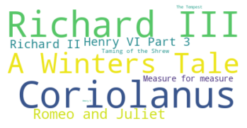

```python
# Visualize types of play
(df.play.explode().value_counts()
 .pipe(value_ct_wordcloud))
```

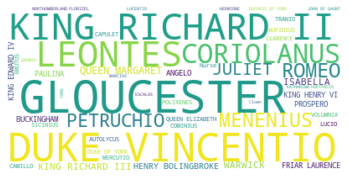

```python
# Visualize types of speaker
(df.speaker.explode().value_counts()
 .pipe(value_ct_wordcloud))
```

```python
# Tokenize dialogue
from nltk.tokenize import word_tokenize
df["tokens"] = (df['dialogue']
                .str.replace(r'[^\w\s]', '', regex=True)  # remove punctuation
                .str.lower()  # lower case
                .apply(word_tokenize))
df.head(3)
```

|  | speaker | line | dialogue | play | tokens |
| --- | --- | --- | --- | --- | --- |
| 0 | First Citizen | 1 | Before we proceed any further, hear me speak. | Coriolanus | [before, we, proceed, any, further, hear, me, ... |
| 1 | All | 2 | Speak, speak. | Coriolanus | [speak, speak] |
| 2 | First Citizen | 3 | You are all resolved rather to die than to fam... | Coriolanus | [you, are, all, resolved, rather, to, die, tha... |

```python
# Remove stopwords from tokens
from nltk.corpus import stopwords
sw = stopwords.words("english")
df['tokens'] = df['tokens'].apply(lambda x: [tkn for tkn in x if tkn not in sw])
df.head(3)
```

|  | speaker | line | dialogue | play | tokens |
| --- | --- | --- | --- | --- | --- |
| 0 | First Citizen | 1 | Before we proceed any further, hear me speak. | Coriolanus | [proceed, hear, speak] |
| 1 | All | 2 | Speak, speak. | Coriolanus | [speak, speak] |
| 2 | First Citizen | 3 | You are all resolved rather to die than to fam... | Coriolanus | [resolved, rather, die, famish] |

```python
# Count the number of types
df.tokens.explode().value_counts().head(30)
```

```
thou     1405
thy      1059
shall     845
thee      760
good      671
lord      632
come      628
sir       592
well      565
would     532
ill       467
hath      453
king      448
say       445
let       437
one       423
go        421
love      410
may       406
us        401
make      397
upon      390
yet       386
like      376
must      370
know      350
man       343
tis       328
see       322
death     304
Name: tokens, dtype: int64
```

```python
# Add more stopwords
extra = ['thou','thy','shall','thee','would','hath',
         'let','one','may','us','upon','yet','tis']
sw = sw + extra
```

```python
# Remove extra stopwords from tokens
df['tokens'] = df['tokens'].apply(lambda x: [tkn for tkn in x if tkn not in sw])
df.tail(3)
```

|  | speaker | line | dialogue | play | tokens |
| --- | --- | --- | --- | --- | --- |
| 25635 | ANTONIO | 7222 | Noble Sebastian, | The Tempest | [noble, sebastian] |
| 25636 | ANTONIO | 7222 | Thou let'st thy fortune sleep--die, rather; wi... | The Tempest | [letst, fortune, sleepdie, rather, winkst] |
| 25637 | ANTONIO | 7222 | Whiles thou art waking. | The Tempest | [whiles, art, waking] |

```python
# Generate word clouds for the 10 most frequent speakers
speakers = df.speaker.explode().value_counts().head(10).index.tolist()
df.speaker.explode().value_counts().head(10)
```

```
GLOUCESTER         904
DUKE VINCENTIO     824
KING RICHARD II    760
LEONTES            679
CORIOLANUS         676
ROMEO              604
MENENIUS           587
PETRUCHIO          568
JULIET             551
QUEEN MARGARET     498
Name: speaker, dtype: int64
```

```python
speakers[0]
```

```
'GLOUCESTER'
```

```python
# Generate word cloud for a speaker
def speaker_wordcloud(name):
    return (df[df.speaker == name]
            .tokens.explode().value_counts()
            .pipe(value_ct_wordcloud))
```

```
GLOUCESTER
```

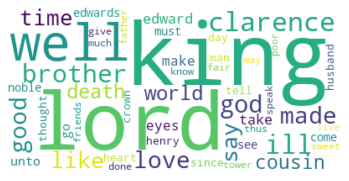

```
DUKE VINCENTIO
```

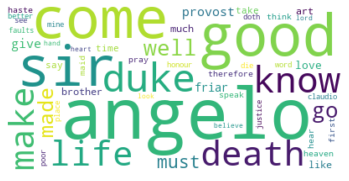

```
KING RICHARD II
```

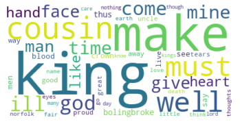

```
LEONTES
```

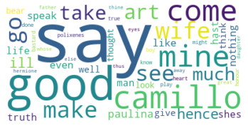

```
CORIOLANUS
```

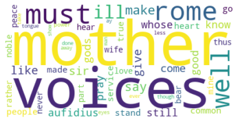

```
ROMEO
```

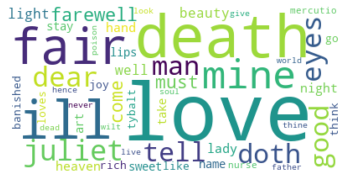

```
MENENIUS
```

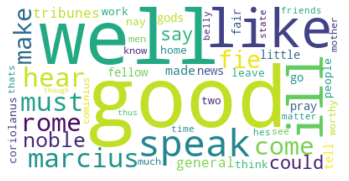

```
PETRUCHIO
```

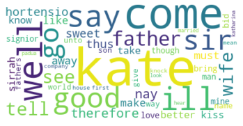

```
JULIET
```

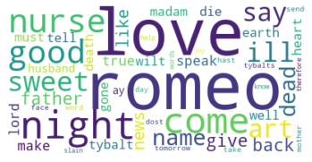

```
QUEEN MARGARET
```

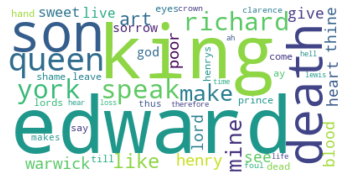

```python
# Visualize keywords of a speaker
for name in speakers:
    print(name)
    speaker_wordcloud(name)
```

The word clouds above explore how interesting the speakers are. Juliet, for example, is all about love and Romeo, while Queen Margaret mentions a ton about the King and Edward. One weakness of this method is that some keywords do not necessarily represent meanings, but rather the name of the person talking to the speaker.